# rsmFlow: GLM and Nonlinear Response Surfaces

# GLM and nonlinear response surfaces

**Role in the vignette curriculum.** This deep dive owns non-Gaussian two-factor response surfaces, response-scale interpretation, offsets/weights, nonlinear biological models, GA/multistart initialization, optional `gnls`, and nonlinear identifiability diagnostics. General optimization and uncertainty are developed in the next vignette.

## 1. Why move beyond Gaussian quadratic RSM?

A second-order Gaussian surface is a local approximation. It is often excellent for designed experiments, but response data can violate its assumptions or encode biological mechanisms that a polynomial does not express naturally.

Two broad alternatives are implemented in `rsmFlow`:

1. **GLM response surfaces:** keep a hierarchical quadratic predictor but model a non-Gaussian response through a link function.
2. **Nonlinear response surfaces:** replace the polynomial mean with a biologically interpretable nonlinear function.

These are different modeling decisions. A nonlinear model is not simply a GLM with another link, and a GLM is not simply a transformed Gaussian regression.

## 2. A common two-factor quadratic predictor for GLMs

For factors $x_1$ and $x_2$,

$$g(\mu) = \beta_0 + \beta_1x_1 + \beta_2x_2 + \beta_{11}x_1^2 +
\beta_{22}x_2^2 + \beta_{12}x_1x_2.$$

The link $g(\cdot)$ maps the mean response to the linear predictor.

```r
library(rsmFlow)
```

## 3. Poisson example: pest counts

Create a realistic dose × exposure-time teaching dataset.

```r
set.seed(501)
grid <- expand.grid(
  Dose = seq(0, 1, length.out=7),
  Time = seq(0, 1, length.out=7)
)

eta <- 3.8 - 1.9*grid$Dose - 0.8*grid$Time +
  0.9*grid$Dose^2 + 0.4*grid$Time^2 - 0.5*grid$Dose*grid$Time
mu <- exp(eta)
grid$Count <- rpois(nrow(grid), mu)
```

Fit:

```r
pois_fit <- rsm_glm_fit(
  grid,
  response="Count",
  factors=c("Dose","Time"),
  order=2,
  family=poisson()
)
summary(pois_fit)
```

```
#> rsmFlow GLM response-surface summary
#>
#>
#> Call:
#> stats::glm(formula = form, family = ff$family, data = fit_data,
#>     weights = weights, na.action = na.action, model = TRUE, x = TRUE,
#>     y = TRUE)
#>
#> Coefficients:
#>             Estimate Std. Error z value Pr(>|z|)
#> (Intercept)  3.84738    0.09626  39.969  < 2e-16 ***
#> Dose        -1.94006    0.36162  -5.365  8.1e-08 ***
#> Time        -0.85246    0.36027  -2.366   0.0180 *
#> I(Dose^2)    0.83002    0.35346   2.348   0.0189 *
#> I(Time^2)    0.43353    0.34156   1.269   0.2044
#> Dose:Time   -0.33460    0.30232  -1.107   0.2684
#> ---
#> Signif. codes:  0 '***' 0.001 '**' 0.01 '*' 0.05 '.' 0.1 ' ' 1
#>
#> (Dispersion parameter for poisson family taken to be 1)
#>
#>     Null deviance: 242.513  on 48  degrees of freedom
#> Residual deviance:  27.251  on 43  degrees of freedom
#> AIC: 267.12
#>
#> Number of Fisher Scoring iterations: 4
#>
#>
#> Dispersion diagnostic
#> $family
#> [1] "poisson"
#>
#> $link
#> [1] "log"
#>
#> $pearson_dispersion
#> [1] 0.6052316
#>
#> $residual_deviance
#> [1] 27.25083
#>
#> $df_residual
#> [1] 43
#>
#> $dispersion_fixed_by_family
#> [1] TRUE
#>
#> $interpretation
#> [1] "Interpret dispersion jointly with residual diagnostics and the data-generating process."
```

### Why the response scale matters

The polynomial is quadratic on the log-mean scale, but the operational response is $\mu=\exp(\eta)$. Therefore, contour geometry on the response scale can differ visually from the link scale.

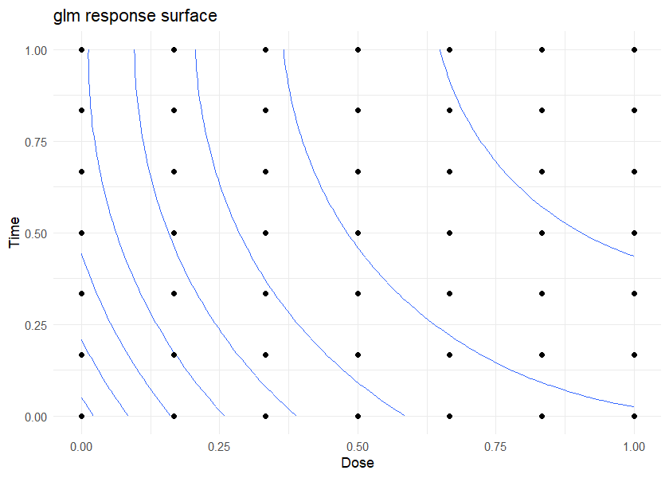

```r
rsm_plot(pois_fit, type="contour", scale="response")
```

```
#> Ignoring unknown labels:
#> • fill : "Count"
```

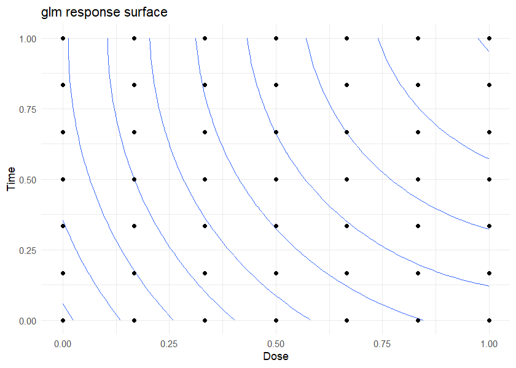

```r
rsm_plot(pois_fit, type="contour", scale="link")
```

For scientific recommendations, the response scale is usually the primary scale.

## 4. Dispersion diagnostics

```r
disp <- rsm_glm_dispersion(pois_fit)
disp
```

```
#> $family
#> [1] "poisson"
#>
#> $link
#> [1] "log"
#>
#> $pearson_dispersion
#> [1] 0.6052316
#>
#> $residual_deviance
#> [1] 27.25083
#>
#> $df_residual
#> [1] 43
#>
#> $dispersion_fixed_by_family
#> [1] TRUE
#>
#> $interpretation
#> [1] "Interpret dispersion jointly with residual diagnostics and the data-generating process."
```

A Pearson-type dispersion substantially larger than one suggests that the Poisson variance may be too restrictive. This is evidence, not an automatic family switch.

Check broader diagnostics:

```r
gd <- rsm_glm_diagnostics(pois_fit)
gd
```

```
#> $family
#> [1] "poisson"
#>
#> $link
#> [1] "log"
#>
#> $deviance_residuals
#>  [1]  0.16436149  0.21721991  0.20651933  0.02898136 -0.86302966 -1.45628553
#>  [7]  0.14017124 -0.18091601  0.85214339 -0.25202370  0.74922297  0.06739034
#> [13]  0.29629139  0.85279061 -0.50298805 -0.37281280  0.75555360 -0.85514020
#> [19] -1.03361747  0.58638028  0.02673988  0.15205647 -0.52714682 -0.60157446
#> [25]  0.84899789 -0.93504980  0.15824238  1.07182744  0.31552666  0.21284513
#> [31]  0.19967171  0.41968446  1.13986296  0.49276605 -0.90178943 -0.57019927
#> [37] -0.00121229 -2.28121113 -1.07749645 -0.40010500  0.74240005  0.08515812
#> [43]  0.20961131  0.08718588  1.46123859  0.78375581  0.38059177 -0.82124783
#> [49] -1.32688421
#>
#> $pearson_residuals
#>  [1]  0.165017842  0.218550618  0.207884838  0.029011282 -0.833734725
#>  [6] -1.366555740  0.141002008 -0.180063658  0.873893468 -0.249816346
#> [11]  0.770575547  0.067580900  0.300192963  0.886001791 -0.496008810
#> [16] -0.368320047  0.776294169 -0.824417507 -0.984175683  0.602754545
#> [21]  0.026775930  0.152714879 -0.517717310 -0.587392594  0.879852464
#> [26] -0.892152337  0.159526168  1.132270218  0.318437719  0.214414705
#> [31]  0.201269134  0.427619900  1.203416716  0.505765100 -0.853955678
#> [36] -0.560401581 -0.001212237 -2.054274790 -1.021549261 -0.391683307
#> [41]  0.772899601  0.085590862  0.210926068  0.087458091  1.548159209
#> [46]  0.812588910  0.388233434 -0.781081639 -1.212877208
#>
#> $fitted
#>  [1] 46.870257 34.712361 26.921373 21.864345 18.595248 16.561273 15.445845
#>  [8] 41.155149 30.197740 23.203362 18.670400 15.731950 13.881543 12.826824
#> [15] 37.017831 26.910679 20.486349 16.331674 13.633994 11.919051 10.911552
#> [22] 34.108112 24.566020 18.528410 14.634158 12.103850 10.483483  9.508540
#> [29] 32.193214 22.972322 17.166102 13.432743 11.007380  9.445597  8.487917
#> [36] 31.126546 22.005687 16.291653 12.630531 10.254259  8.717926  7.761548
#> [43] 30.828860 21.593592 15.838664 12.165737  9.785534  8.242461  7.270353
#>
#> $leverage
#>  [1] 0.43428235 0.19827071 0.15432974 0.14167790 0.13795782 0.17106045
```

[output cut: 48 more lines]

```
#>
#> $dispersion$pearson_dispersion
#> [1] 0.6052316
#>
#> $dispersion$residual_deviance
#> [1] 27.25083
#>
#> $dispersion$df_residual
#> [1] 43
#>
#> $dispersion$dispersion_fixed_by_family
#> [1] TRUE
#>
#> $dispersion$interpretation
#> [1] "Interpret dispersion jointly with residual diagnostics and the data-generating process."
```

## 5. Negative Binomial alternative

```r
if (requireNamespace("MASS", quietly=TRUE)) {
  nb_fit <- rsm_glm_fit(
    grid,
    response="Count",
    factors=c("Dose","Time"),
    order=2,
    family="negative_binomial"
  )
  rsm_compare_engines(pois_fit, nb_fit)
}
```

[output not shown]

### Interpretation

Prefer Negative Binomial when extra-Poisson variability is scientifically and diagnostically supported. Do not fit it simply because it has an additional dispersion parameter.

## 6. Exposure offsets

Suppose counts arise from different sampling efforts.

```r
set.seed(502)
grid$Exposure <- sample(c(5,10,20), nrow(grid), replace=TRUE)
rate_mu <- exp(2.2 - 1.4*grid$Dose + 0.3*grid$Time)
grid$CountExposure <- rpois(nrow(grid), lambda=rate_mu * grid$Exposure)

offset_fit <- rsm_glm_fit(
  grid,
  response="CountExposure",
  factors=c("Dose","Time"),
  family=poisson(),
  offset=log(grid$Exposure),
  offset_reference=log(10)
)
```

The offset separates response intensity from exposure. `offset_reference` supplies a defined exposure when predicting new factor combinations for optimization.

## 7. Binomial example: germination

```r
set.seed(503)
germ <- expand.grid(
  Temperature = seq(18,34,length.out=7),
  Salinity = seq(0,8,length.out=7)
)

eta <- 2.2 - 0.055*(germ$Temperature-26)^2 -
  0.28*germ$Salinity - 0.035*germ$Salinity^2
p <- plogis(eta)
germ$Trials <- sample(c(30,50,80), nrow(germ), replace=TRUE)
germ$Success <- rbinom(nrow(germ), germ$Trials, p)
germ$Proportion <- germ$Success/germ$Trials
```

Fit a proportion with trial weights:

```r
bin_fit <- rsm_glm_fit(
  germ,
  response="Proportion",
  factors=c("Temperature","Salinity"),
  family=binomial(),
  weights=germ$Trials
)
```

Plot probability contours:

```
#> Ignoring unknown labels:
#> • fill : "Proportion"
```

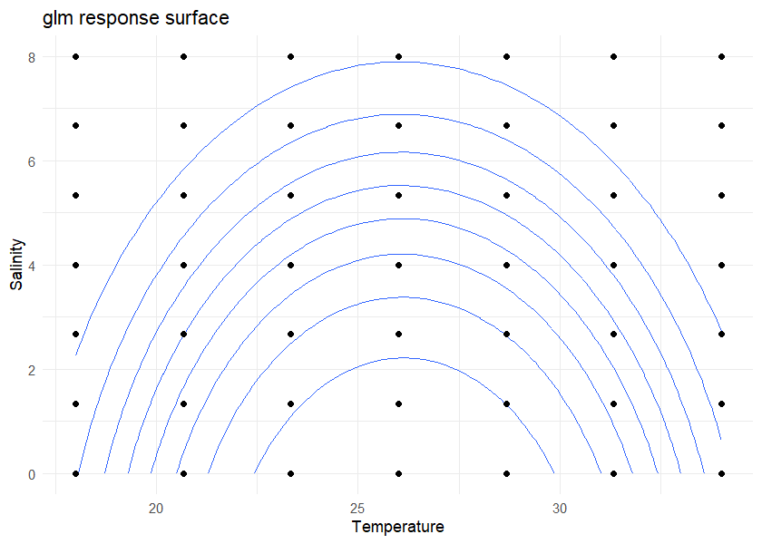

```r
rsm_plot(bin_fit, type="contour", scale="response")
```

### Interpretation

A proportion based on 80 trials is more informative than the same proportion based on 5 trials. Trial weights are therefore part of the sampling model, not optional cosmetics.

## 8. Quasi-binomial and quasi-Poisson

When mean structure is useful but variance departs from a full likelihood family:

```r
qpois_fit <- rsm_glm_fit(
  grid,
  "Count",
  c("Dose","Time"),
  family=quasipoisson()
)

qbin_fit <- rsm_glm_fit(
  germ,
  "Proportion",
  c("Temperature","Salinity"),
  family=quasibinomial(),
  weights=germ$Trials
)
```

Do not compare quasi-family candidates using likelihood AIC as if they were ordinary likelihood models.

## 9. Gamma response surface

For positive, right-skewed continuous responses such as waiting time, concentration, or energy use:

```r
set.seed(504)
gamdat <- expand.grid(
  Temperature=seq(20,40,length.out=7),
  Moisture=seq(0.2,0.8,length.out=7)
)
mean_y <- exp(2.0 + 0.03*(gamdat$Temperature-30) -
  1.8*(gamdat$Moisture-0.5)^2)
shape <- 20
gamdat$Response <- rgamma(nrow(gamdat), shape=shape, scale=mean_y/shape)

gamma_fit <- rsm_glm_fit(
  gamdat,
  "Response",
  c("Temperature","Moisture"),
  family=Gamma(link="log")
)
```

Use the response scale for operational interpretation.

## 10. Inverse Gaussian response surface

```r
# Example family specification:
# inv_fit <- rsm_glm_fit(
#   dat_pos,
#   "Duration",
#   c("Temperature","Pressure"),
#   family=inverse.gaussian(link="log")
# )
```

The family should be chosen because its mean-variance relationship and support fit the scientific response, not because it is available in a menu.

## 11. GLM lack of fit

When replicated factor cells exist:

```r
rsm_glm_lack_of_fit(pois_fit)
```

```
#> $available
#> [1] TRUE
#>
#> $delta_deviance
#> [1] 27.25083
#>
#> $df
#> [1] 43
#>
#> $statistic
#> [1] 27.25083
#>
#> $p.value
#> [1] 0.9707021
#>
#> $method
#> [1] "deviance chi-square approximation"
#>
#> $reference
#> [1] "cell-means GLM"
```

Use this alongside residual diagnostics and dispersion. A non-Gaussian response can have an appropriate family but still have an inadequate mean surface.

## 12. Response-scale canonical analysis

```r
gcan <- rsm_glm_canonical(bin_fit)
gcan
```

```
#> Canonical analysis
#> Nature: maximum
#> Stationary point:
#> Temperature    Salinity
#>   26.188191   -3.402223
#> Predicted response: 0.9285241
#> Inside region: FALSE
#> Warning: Stationary point lies outside the declared experimental region; use bounded optimization for operational decisions.
```

Unlike a Gaussian identity-link quadratic, response-scale curvature under a nonlinear link is not interpreted by blindly reusing link-scale coefficients. `rsm_glm_canonical()` uses response-scale numerical derivatives for operational classification.

## 13. Optimize a GLM surface

```r
opt_pest <- rsm_optimize(
  pois_fit,
  goal="min",
  method="L-BFGS-B",
  scale="response"
)
opt_pest
```

```
#> rsmFlow optimum
#> Goal: min  | method: L-BFGS-B
#> Dose Time
#>    1    1
#> Predicted response: 7.270353
```

```r
opt_germ <- rsm_optimize(
  bin_fit,
  goal="max",
  method="L-BFGS-B",
  scale="response"
)
opt_germ
```

```
#> rsmFlow optimum
#> Goal: max  | method: L-BFGS-B
#> Temperature    Salinity
#>    26.14783     0.00000
#> Predicted response: 0.8940197
```

Always state whether the reported objective is mean count, probability, rate at a reference exposure, or another response-scale quantity.

# Part II. Nonlinear response surfaces

## 14. Why use a biologically motivated nonlinear model?

Quadratic polynomials are local. A nonlinear model can encode saturation, asymptotes, plateaus, or multiplicative factor response more directly (Landes et al. 1999; Frenzel et al. 2010).

Inspect the catalog:

```r
rsm_nonlinear_models()
```

```
#>                   model    parameters
#> 1 mitscherlich2_product       A,k1,k2
#> 2  mitscherlich2_offset A,k1,k2,b1,b2
#> 3     gompertz2_product A,b1,k1,b2,k2
#> 4     michaelis_menten2       A,K1,K2
#> 5           asymptotic2 A,B1,k1,B2,k2
#> 6                hoerl2 A,b1,c1,b2,c2
#> 7       linear_plateau2 A,s1,t1,s2,t2
#> 8    quadratic_plateau2 A,c1,t1,c2,t2
#> 9                custom  user-defined
#>                                   interpretation
#> 1                      multiplicative saturation
#> 2         multiplicative saturation with offsets
#> 3             multiplicative Gompertz saturation
#> 4         two-factor Michaelis-Menten saturation
#> 5                   additive asymptotic response
#> 6                       two-factor Hoerl surface
#> 7           increasing two-factor linear plateau
#> 8 smooth increasing two-factor quadratic plateau
#> 9                       custom nonlinear formula
```

Families include Mitscherlich, Gompertz, Michaelis-Menten, asymptotic, Hoerl, linear plateau, quadratic plateau, and custom formulas.

## 15. Mitscherlich two-factor product model

Create a saturating fertilizer response:

```r
set.seed(510)
nd <- expand.grid(
  N=seq(0,160,length.out=7),
  P=seq(0,90,length.out=7)
)

A <- 11
kN <- 0.026
kP <- 0.041
nd$Yield <- A*(1-exp(-kN*nd$N))*(1-exp(-kP*nd$P)) +
  rnorm(nrow(nd),0,0.08)
```

Fit with GA-assisted starts:

```r
nl_ga <- rsm_nonlinear_fit(
  nd,
  response="Yield",
  factors=c("N","P"),
  model="mitscherlich2_product",
  start="ga",
  engine="nlsLM",
  seed=511
)
nl_ga
```

```
#> rsmFlow nonlinear two-factor surface
#> Response: Yield
#> Factors: N, P
#> Model: mitscherlich2_product
#> Engine: nlsLM
#> Start search: GA
```

## 16. GA is a starting-value search, not the estimator

The workflow is:

**parameter bounds -> GA search -> starting vector -> nonlinear least squares -> final covariance/diagnostics.**

The final estimator remains `nlsLM`, `nls`, or optional `gnls`.

This distinction should be explicit in Methods sections.

## 17. Direct GA start search

```r
form <- Yield ~ A*(1-exp(-kN*N))*(1-exp(-kP*P))

start_ga <- rsm_nonlinear_start_ga(
  data=nd,
  formula=form,
  start_bounds=list(
    lower=c(A=8, kN=0.001, kP=0.001),
    upper=c(A=15, kN=0.10, kP=0.10)
  ),
  seed=512,
  ga_control=list(popSize=100,maxiter=400,run=80)
)
start_ga
```

```
#> $start
#>           A          kN          kP
#> 10.99286132  0.02623105  0.04109474
#>
#> $SSE
#> [1] 0.3461963
#>
#> $engine
#> [1] "GA"
#>
#> $ga
#> An object of class "ga"
#>
#> Call:
#> GA::ga(type = "real-valued", fitness = function(p) -sse(p), lower = b$lower,     upper = b$upper, popSize = ctrl$popSize, maxiter = ctrl$maxiter,     run = ctrl$run, monitor = FALSE, seed = seed)
#>
#> Available slots:
#>  [1] "call"         "type"         "lower"        "upper"        "nBits"
#>  [6] "names"        "popSize"      "iter"         "run"          "maxiter"
#> [11] "suggestions"  "population"   "elitism"      "pcrossover"   "pmutation"
#> [16] "optim"        "fitness"      "summary"      "bestSol"      "fitnessValue"
#> [21] "solution"
#>
#> $bounds
#> $bounds$lower
#>     A    kN    kP
#> 8.000 0.001 0.001
#>
#> $bounds$upper
#>    A   kN   kP
#> 15.0  0.1  0.1
```

## 18. Multistart alternative

```r
start_ms <- rsm_nonlinear_start_multistart(
  data=nd,
  formula=form,
  start_bounds=list(
    lower=c(A=8, kN=0.001, kP=0.001),
    upper=c(A=15, kN=0.10, kP=0.10)
  ),
  n_start=1000,
  seed=512
)
start_ms
```

```
#> $start
#>           A          kN          kP
#> 11.63659238  0.02528356  0.03546244
#>
#> $SSE
#> [1] 1.897694
#>
#> $engine
#> [1] "random_multistart"
#>
#> $evaluated
#> [1] 1000
#>
#> $bounds
#> $bounds$lower
#>     A    kN    kP
#> 8.000 0.001 0.001
#>
#> $bounds$upper
#>    A   kN   kP
#> 15.0  0.1  0.1
```

Compare GA and multistart under the same bounds and frozen seeds rather than assuming one is universally superior.

## 19. Nonlinear diagnostics

```r
nd_diag <- rsm_nonlinear_diagnostics(nl_ga)
nd_diag
```

```
#> $converged
#> [1] TRUE
#>
#> $engine
#> [1] "nlsLM"
#>
#> $model
#> [1] "mitscherlich2_product"
#>
#> $coefficients
#>           A          k1          k2
#> 10.99357399  0.02624247  0.04107981
#>
#> $RSS
#> [1] 0.3461654
#>
#> $RMSE
#> [1] 0.08405118
#>
#> $logLik
#> [1] 51.81215
#>
#> $AIC
#> [1] -95.62431
#>
#> $BIC
#> [1] -88.05703
#>
#> $jacobian_singular_values
#> [1] 568.829993 233.458165   1.894085
#>
#> $jacobian_condition
#> [1] 300.3191
#>
#> $parameter_correlation
#>             A            k1            k2
#> A   1.0000000 -5.842851e-01 -6.782588e-01
#> k1 -0.5842851  1.000000e+00 -1.104261e-08
#> k2 -0.6782588 -1.104261e-08  1.000000e+00
#>
#> $start_engine
#> [1] "GA"
#>
#> $start_SSE
#> [1] 0.3477194
#>
#> $warning
#> NULL
```

Inspect:

- convergence status;
- residual pattern;
- parameter covariance/correlation when available;
- numerical prediction-Jacobian singular values;
- Jacobian condition number;
- evidence of weak identifiability;
- start-search metadata.

### Interpretation

A low residual RMSE can coexist with poorly identified parameters. For biological models, parameter identifiability is as important as fitted response error.

## 20. Compare final solutions from GA and multistart

```r
nl_ms <- rsm_nonlinear_fit(
  nd,
  "Yield",
  c("N","P"),
  model="mitscherlich2_product",
  start="multistart",
  n_start=1000,
  engine="nlsLM",
  seed=512
)

rsm_compare_engines(nl_ga, nl_ms)
```

[output not shown]

```r
rsm_compare_optima(
  rsm_optimize(nl_ga, goal="max"),
  rsm_optimize(nl_ms, goal="max")
)
```

```
#>       name   N  P predicted method
#> 1 optimum1 160 90  10.56005   grid
#> 2 optimum2 160 90  10.56005   grid
```

Similar fitted error is reassuring only if parameter interpretation and operational decisions are also stable.

## 21. Michaelis-Menten two-factor model

```r
set.seed(513)
mm <- expand.grid(x1=seq(1,100,length.out=8), x2=seq(1,80,length.out=8))
mm$y <- 15*(mm$x1/(30+mm$x1))*(mm$x2/(20+mm$x2)) + rnorm(nrow(mm),0,0.12)

mm_fit <- rsm_nonlinear_fit(
  mm,
  "y",
  c("x1","x2"),
  model="michaelis_menten2",
  start="ga",
  seed=514
)
```

Use when enzyme-like or saturating factor kinetics are scientifically plausible.

## 22. Gompertz and asymptotic forms

```r
# gom_fit <- rsm_nonlinear_fit(dat, "Response", c("x1","x2"),
#   model="gompertz2_product", start="ga", seed=515)
#
# asym_fit <- rsm_nonlinear_fit(dat, "Response", c("x1","x2"),
#   model="asymptotic2", start="ga", seed=515)
```

Select by biological meaning and fit adequacy, not by name familiarity.

## 23. Linear and quadratic plateau models

```r
# lp <- rsm_nonlinear_fit(dat, "Yield", c("N","P"),
#   model="linear_plateau2", start="ga", seed=516)
#
# qp <- rsm_nonlinear_fit(dat, "Yield", c("N","P"),
#   model="quadratic_plateau2", start="ga", seed=516)
```

Plateau models are attractive when the scientific question concerns a threshold beyond which more input produces negligible biological gain. Their continuity and breakpoint parameterization must be checked numerically during local validation before formal inference.

## 24. Custom nonlinear formula

```r
custom_formula <- Yield ~ A *
  (1-exp(-k1*N)) *
  (1-exp(-k2*P)) + c0

custom_fit <- rsm_nonlinear_fit(
  nd,
  response="Yield",
  factors=c("N","P"),
  model="custom",
  formula=custom_formula,
  start="ga",
  start_bounds=list(
    lower=c(A=8, k1=.001, k2=.001, c0=-2),
    upper=c(A=15, k1=.1, k2=.1, c0=2)
  ),
  seed=517
)
```

A custom formula expands flexibility but also transfers responsibility for parameterization, bounds, starting values, and biological plausibility to the analyst.

## 25. `nls`, `nlsLM`, and `gnls`

Base `nls`:

```r
fit_nls <- rsm_nonlinear_fit(
  nd,"Yield",c("N","P"),
  model="mitscherlich2_product",
  start="ga", engine="nls", seed=518
)
```

Levenberg-Marquardt via optional `minpack.lm`:

```r
fit_lm <- rsm_nonlinear_fit(
  nd,"Yield",c("N","P"),
  model="mitscherlich2_product",
  start="ga", engine="nlsLM", seed=518
)
```

Generalized nonlinear least squares via optional `nlme`:

```r
fit_gnls <- rsm_nonlinear_fit(
  nd,"Yield",c("N","P"),
  model="mitscherlich2_product",
  start="ga", engine="gnls",
  variance="power",
  seed=518
)
```

### Interpretation

Use `gnls` when residual variance/correlation structure is scientifically relevant. Do not choose it only because it is more complex. Backend compatibility and uncertainty simulation must be runtime-validated in the installed `nlme` version.

## 26. Visualize nonlinear surfaces

```r
rsm_plot(nl_ga, type="surface", interactive=TRUE)
```

[interactive chart not shown]

```
#> Ignoring unknown labels:
#> • fill : "Yield"
```

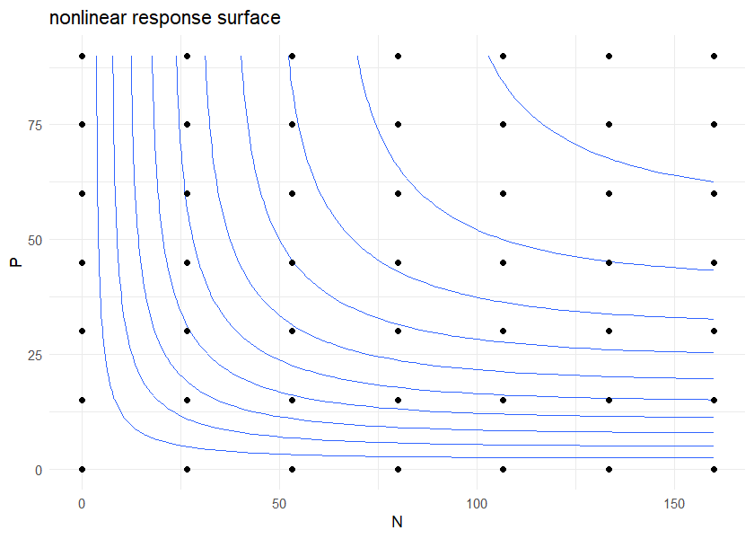

```r
rsm_plot(nl_ga, type="contour")
```

```r
rsm_profile(nl_ga, factor="N", at=list(P=60))
```

```
#>              N  P predicted     lower     upper
#> 1     0.000000 60 0.0000000 0.0000000 0.0000000
#> 2     1.616162 60 0.4176953 0.4108346 0.4245560
#> 3     3.232323 60 0.8180457 0.8049600 0.8311313
#> 4     4.848485 60 1.2017714 1.1830548 1.2204880
#> 5     6.464646 60 1.5695628 1.5457698 1.5933558
#> 6     8.080808 60 1.9220816 1.8937297 1.9504335
#> 7     9.696970 60 2.2599620 2.2275334 2.2923905
#> 8    11.313131 60 2.5838117 2.5477558 2.6198677
#> 9    12.929293 60 2.8942136 2.8549481 2.9334791
#> 10   14.545455 60 3.1917259 3.1496394 3.2338124
#> 11   16.161616 60 3.4768840 3.4323370 3.5214309
#> 12   17.777778 60 3.7502007 3.7035278 3.7968737
#> 13   19.393939 60 4.0121680 3.9636787 4.0606573
#> 14   21.010101 60 4.2632570 4.2132376 4.3132763
```

[output cut: 86 more lines]

Profiles often communicate saturation more clearly than parameter tables.

## 27. Three model-selection questions

Before replacing classical RSM with a nonlinear model ask:

1. Does biology motivate the nonlinear structure?
2. Are nonlinear parameters identifiable in the experimental range?
3. Does the nonlinear model change prediction or the practical optimum enough to matter?

`rsm_compare_engines()` and `rsm_compare_optima()` are designed to keep these questions separate.

## 28. Common mistakes

1. Choosing Poisson solely because the response is integer.
2. Ignoring exposure offsets in rate data.
3. Optimizing GLM link scale when the decision is on response scale.
4. Using AIC to rank quasi-likelihood models indiscriminately.
5. Calling GA the nonlinear estimator.
6. Reporting nonlinear parameters without identifiability diagnostics.
7. Treating a quadratic plateau breakpoint as known precisely without uncertainty analysis.
8. Extrapolating a saturating curve far beyond the observed range.

## 29. Minimum reporting checklist

- Response support and family justified.
- Link function reported.
- Weights/offset/exposure documented.
- Dispersion checked for counts.
- GLM diagnostics reported.
- Optimization scale stated.
- Nonlinear model equation reported.
- Starting-value method reported.
- GA explicitly distinguished from final estimator.
- Parameter bounds and seed documented.
- Convergence and Jacobian condition examined.
- Residual variance/correlation structure reported for `gnls`.
- Extrapolation limits stated.

## 30. Where to go next

Continue to **Optimization, Uncertainty, and Economics** to propagate fitted-model uncertainty into operating decisions and distinguish a biological optimum from an economic recommendation.

Frenzel, M. J., W. W. Stroup, and E. T. Paparozzi. 2010. “After Further Review: An Update on Modeling and Design Strategies for Agricultural Dose-Response Experiments.” *Conference on Applied Statistics in Agriculture*. https://doi.org/10.4148/2475-7772.1070.

Landes, R. D., W. W. Stroup, E. T. Paparozzi, and M. E. Conley. 1999. “Nonlinear Models for Multi-Factor Plant Nutrition Experiments.” *Conference on Applied Statistics in Agriculture*. https://doi.org/10.4148/2475-7772.1263.